# Section_10_Prophet_Library

#### Prophet Forecast Evaluations

```python
### Load Data

df = pd.read_csv('Chapter_8_Miles_Traveled.csv')
df.head()
```

|  | DATE | TRFVOLUSM227NFWA |
| --- | --- | --- |
| 0 | 1970-01-01 | 80173.0 |
| 1 | 1970-02-01 | 77442.0 |
| 2 | 1970-03-01 | 90223.0 |
| 3 | 1970-04-01 | 89956.0 |
| 4 | 1970-05-01 | 97972.0 |

```python
df.columns = ['ds','y']
df['ds'] = pd.to_datetime(df['ds'])
df.head()
```

|  | ds | y |
| --- | --- | --- |
| 0 | 1970-01-01 | 80173.0 |
| 1 | 1970-02-01 | 77442.0 |
| 2 | 1970-03-01 | 90223.0 |
| 3 | 1970-04-01 | 89956.0 |
| 4 | 1970-05-01 | 97972.0 |

```python
df.tail()
```

|  | ds | y |
| --- | --- | --- |
| 583 | 2018-08-01 | 286608.0 |
| 584 | 2018-09-01 | 260595.0 |
| 585 | 2018-10-01 | 282174.0 |
| 586 | 2018-11-01 | 258590.0 |
| 587 | 2018-12-01 | 268413.0 |

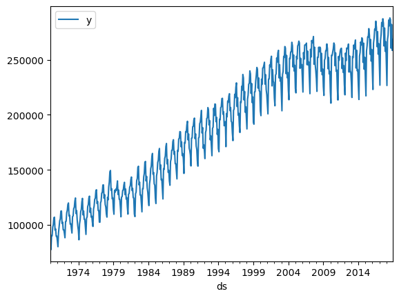

```python
df.plot(x='ds', y='y');
```

```python
### When evaluating the model, we also consider Prophet diagnostic tools in addition to RMSE.
```

```python
len(df)
```

```
588
```

```python
train = df.iloc[:576]
test = df.iloc[576:]
```

```python
m = Prophet()
m.fit(train)
future = m.make_future_dataframe(periods=12, freq='MS')
forecasts = m.predict(future)
```

```
14:35:49 - cmdstanpy - INFO - Chain [1] start processing
14:35:49 - cmdstanpy - INFO - Chain [1] done processing
```

```python
forecasts.tail()
```

|  | ds | trend | yhat_lower | yhat_upper | trend_lower | trend_upper | additive_terms | additive_terms_lower | additive_terms_upper | yearly | yearly_lower | yearly_upper | multiplicative_terms | multiplicative_terms_lower | multiplicative_terms_upper | yhat |
| --- | --- | --- | --- | --- | --- | --- | --- | --- | --- | --- | --- | --- | --- | --- | --- | --- |
| 583 | 2018-08-01 | 263433.961363 | 274137.747815 | 285667.990308 | 263380.173539 | 263479.735426 | 16446.099553 | 16446.099553 | 16446.099553 | 16446.099553 | 16446.099553 | 16446.099553 | 0.0 | 0.0 | 0.0 | 279880.060915 |
| 584 | 2018-09-01 | 263576.193572 | 255716.984564 | 266980.580201 | 263490.429034 | 263652.839785 | -1672.201466 | -1672.201466 | -1672.201466 | -1672.201466 | -1672.201466 | -1672.201466 | 0.0 | 0.0 | 0.0 | 261903.992106 |
| 585 | 2018-10-01 | 263713.837645 | 263269.436135 | 274753.290750 | 263598.405252 | 263825.585106 | 5303.861138 | 5303.861138 | 5303.861138 | 5303.861138 | 5303.861138 | 5303.861138 | 0.0 | 0.0 | 0.0 | 269017.698784 |
| 586 | 2018-11-01 | 263856.069855 | 249965.127930 | 261485.847414 | 263695.360636 | 264010.621564 | -8211.003699 | -8211.003699 | -8211.003699 | -8211.003699 | -8211.003699 | -8211.003699 | 0.0 | 0.0 | 0.0 | 255645.066155 |
| 587 | 2018-12-01 | 263993.713928 | 251754.597009 | 262804.824893 | 263809.054107 | 264186.305437 | -6924.489726 | -6924.489726 | -6924.489726 | -6924.489726 | -6924.489726 | -6924.489726 | 0.0 | 0.0 | 0.0 | 257069.224202 |

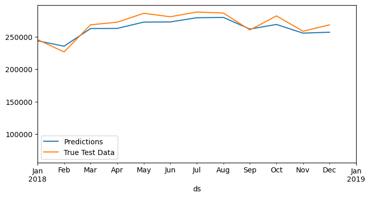

```python
### Plot predicted values with true (observed) values.

ax = forecasts.plot(x='ds', y='yhat', label='Predictions', legend=True, figsize=(8,4)) ### Predictions (including observed data)
test.plot(x='ds', y='y', label='True Test Data', legend=True, ax=ax, xlim=('2018-01-01','2019-01-01'));

### Predictions are closer to the true values
```

```python
### Evaluate accuracy

from statsmodels.tools.eval_measures import rmse
```

```python
predictions = forecasts.iloc[-12:]['yhat']
predictions
```

```
576    243869.249468
577    235498.571820
578    262700.809520
579    262905.134178
580    272630.498100
581    272883.528435
582    279343.142617
583    279880.060915
584    261903.992106
585    269017.698784
586    255645.066155
587    257069.224202
Name: yhat, dtype: float64
```

```python
test['y']
```

```
576    245695.0
577    226660.0
578    268480.0
579    272475.0
580    286164.0
581    280877.0
582    288145.0
583    286608.0
584    260595.0
585    282174.0
586    258590.0
587    268413.0
Name: y, dtype: float64
```

```python
rmse(predictions, test['y'])
```

```
8604.164771919675
```

```python
test['y'].mean()
```

```
268739.6666666667
```

```python
### Compared to the mean value, RMSE is reasonable.
```

Prophet also includes its own diagnostic functionality. It allow us to perform cross-validation.

In the previous example we only check the model based on last part of the data. Howeve, with cross-validation we can evaluate the model with several sections of the data.

```python
from prophet.diagnostics import cross_validation, performance_metrics
from prophet.plot import plot_cross_validation_metric
```

Here, we need to define three different components:

- Initial training period
- The period length we perform cross-validation
- Horizon of prediction in each fold

```python
### Initial training period (5 years)

### Prophet expects in days
initial = 5 * 365
initial = str(initial) + ' days'
initial
```

```
'1825 days'
```

```python
### Period (fold every 5 years)

period = 5 * 365
period = str(period) + ' days'
period
```

```
'1825 days'
```

```python
### Horizon (1 year ahead)

horizon = 365
horizon = str(horizon) + ' days'
horizon
```

```
'365 days'
```

```python
df_cv = cross_validation(model = m, initial=initial, period = period, horizon=horizon)
```

[output not shown]

```python
df_cv.head()
```

|  | ds | yhat | yhat_lower | yhat_upper | y | cutoff |
| --- | --- | --- | --- | --- | --- | --- |
| 0 | 1977-01-01 | 108479.088214 | 107060.172375 | 109801.702720 | 102445.0 | 1976-12-11 |
| 1 | 1977-02-01 | 102996.112258 | 101536.644168 | 104465.917315 | 102416.0 | 1976-12-11 |
| 2 | 1977-03-01 | 118973.319425 | 117564.735447 | 120414.504966 | 119960.0 | 1976-12-11 |
| 3 | 1977-04-01 | 120612.924893 | 119247.527531 | 122155.520381 | 121513.0 | 1976-12-11 |
| 4 | 1977-05-01 | 127883.033113 | 126483.506542 | 129510.948719 | 128884.0 | 1976-12-11 |

```python
len(df_cv)
```

```
108
```

```python
### We can view evaluation for row data

performance_metrics(df_cv)
```

|  | horizon | mse | rmse | mae | mape | mdape | smape | coverage |
| --- | --- | --- | --- | --- | --- | --- | --- | --- |
| 0 | 52 days | 2.444361e+07 | 4944.047949 | 4543.557505 | 0.027822 | 0.023396 | 0.027404 | 0.4 |
| 1 | 53 days | 2.194514e+07 | 4684.563835 | 4278.164994 | 0.025076 | 0.023396 | 0.024777 | 0.4 |
| 2 | 54 days | 1.850353e+07 | 4301.572787 | 3755.478681 | 0.020195 | 0.022195 | 0.020035 | 0.5 |
| 3 | 55 days | 2.338116e+07 | 4835.406657 | 4274.650237 | 0.023245 | 0.023396 | 0.022996 | 0.4 |
| 4 | 57 days | 2.120555e+07 | 4604.948925 | 4014.188335 | 0.021540 | 0.022195 | 0.021331 | 0.5 |
| ... | ... | ... | ... | ... | ... | ... | ... | ... |
| 94 | 360 days | 1.856111e+07 | 4308.260809 | 3760.739729 | 0.019601 | 0.019726 | 0.019607 | 0.5 |
| 95 | 361 days | 1.763881e+07 | 4199.857938 | 3480.778001 | 0.018201 | 0.018870 | 0.018219 | 0.5 |
| 96 | 362 days | 3.198236e+07 | 5655.294891 | 4409.620152 | 0.022013 | 0.024766 | 0.021911 | 0.4 |
| 97 | 364 days | 3.018523e+07 | 5494.108879 | 4241.207268 | 0.021382 | 0.021611 | 0.021293 | 0.5 |
| 98 | 365 days | 5.584118e+07 | 7472.695919 | 5667.821656 | 0.026659 | 0.024790 | 0.026762 | 0.4 |

99 rows × 8 columns

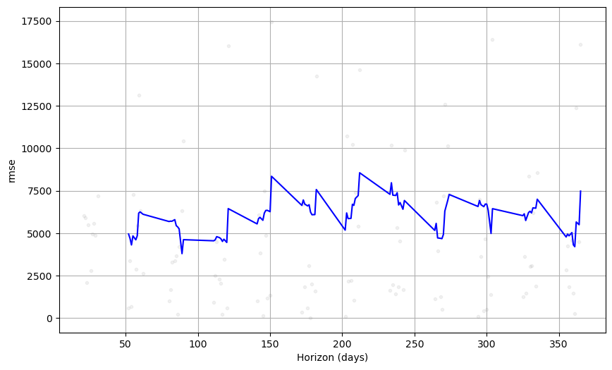

```python
### Since it is hard to read from the row dataframe, we can plot the data using the specific "plot_cross_validation_metric" in Prophet

plot_cross_validation_metric(df_cv, metric='rmse');
```

#### Facebook Prophet Trend and Trend Change Points

Here, we investigate how to use Prophet to identify change points in the trend.

```python
### Load Data

### Note: Hospitality Employees data show clear points in time when the trend changes (along with smaller trend changes).

df = pd.read_csv('Chapter_8_HospitalityEmployees.csv')
df.head()
```

|  | Date | Employees |
| --- | --- | --- |
| 0 | 1/1/1990 | 1064.5 |
| 1 | 2/1/1990 | 1074.5 |
| 2 | 3/1/1990 | 1090.0 |
| 3 | 4/1/1990 | 1097.4 |
| 4 | 5/1/1990 | 1108.7 |

```python
df.columns = ['ds','y']
df['ds'] = pd.to_datetime(df['ds'])
df.head()
```

|  | ds | y |
| --- | --- | --- |
| 0 | 1990-01-01 | 1064.5 |
| 1 | 1990-02-01 | 1074.5 |
| 2 | 1990-03-01 | 1090.0 |
| 3 | 1990-04-01 | 1097.4 |
| 4 | 1990-05-01 | 1108.7 |

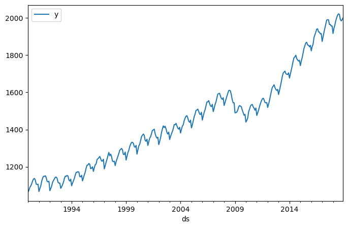

```python
df.plot(x='ds', y='y', figsize=(8,5));

### Significant change in the trend during the recession period.
```

```python
m = Prophet()
m.fit(df)
future = m.make_future_dataframe(periods=12, freq='MS')
forecasts = m.predict(future)
```

```
14:35:57 - cmdstanpy - INFO - Chain [1] start processing
14:35:57 - cmdstanpy - INFO - Chain [1] done processing
```

```python
from prophet.plot import add_changepoints_to_plot
```

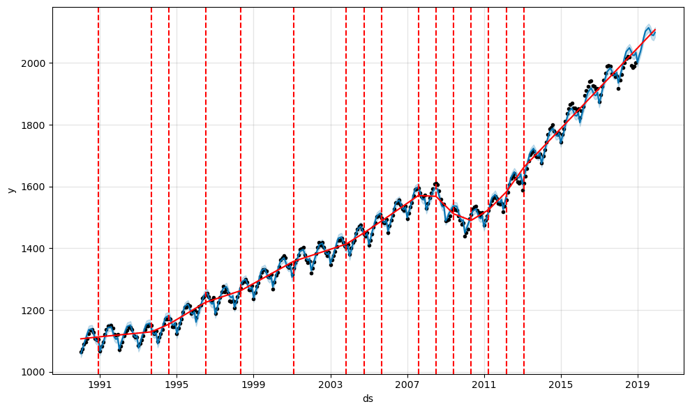

```python
fig = m.plot(forecasts)
a = add_changepoints_to_plot(fig.gca(), m, forecasts); ### gca == get current axis

### This plot shows change points in the trend.
### Based on the data, we have a steadier trend recently.
```

#### Facebook Prophet Seasonality

Here, we investigate how to change seasonality from additive to multiplicative.

```python
### Load Data

df = pd.read_csv('Chapter_5_airline_passengers.csv')
df.head()
```

|  | Month | Thousands of Passengers |
| --- | --- | --- |
| 0 | 1949-01 | 112 |
| 1 | 1949-02 | 118 |
| 2 | 1949-03 | 132 |
| 3 | 1949-04 | 129 |
| 4 | 1949-05 | 121 |

```python
### Prepare Data for Prophet

df.columns = ['ds','y']
df['ds'] = pd.to_datetime(df['ds'])
df.head()
```

|  | ds | y |
| --- | --- | --- |
| 0 | 1949-01-01 | 112 |
| 1 | 1949-02-01 | 118 |
| 2 | 1949-03-01 | 132 |
| 3 | 1949-04-01 | 129 |
| 4 | 1949-05-01 | 121 |

```python
m = Prophet()
m.fit(df)
future = m.make_future_dataframe(periods=50, freq='MS')
forecasts = m.predict(future)
```

```
14:35:58 - cmdstanpy - INFO - Chain [1] start processing
14:35:58 - cmdstanpy - INFO - Chain [1] done processing
```

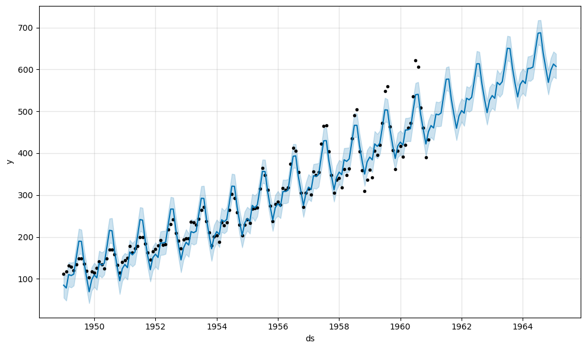

```python
fig = m.plot(forecasts)
```

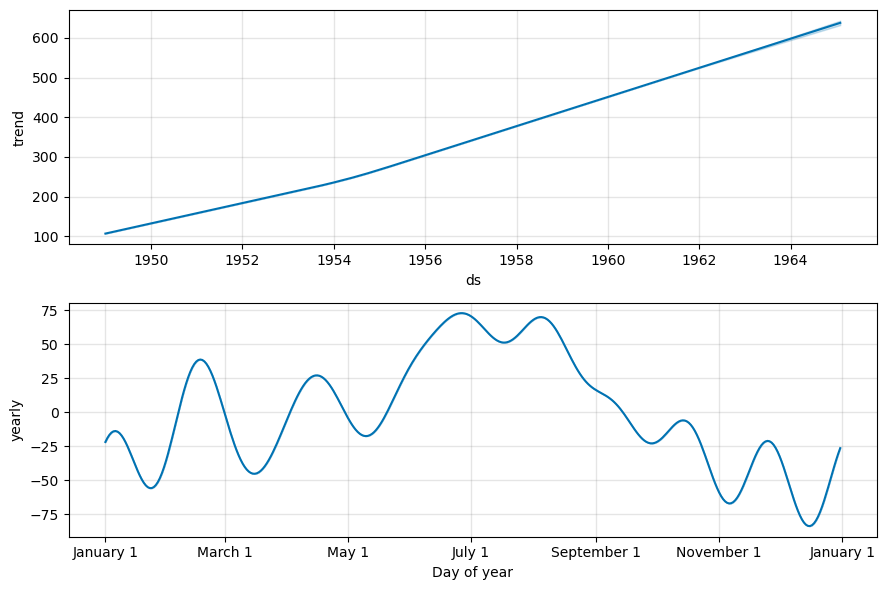

```python
### Let's check components

fig = m.plot_components(forecasts);

### If we carefully investigate, we can see that seasonality grows with trend. Thus, it is multiplicative.
### However, our forecasts do not capture this.
```

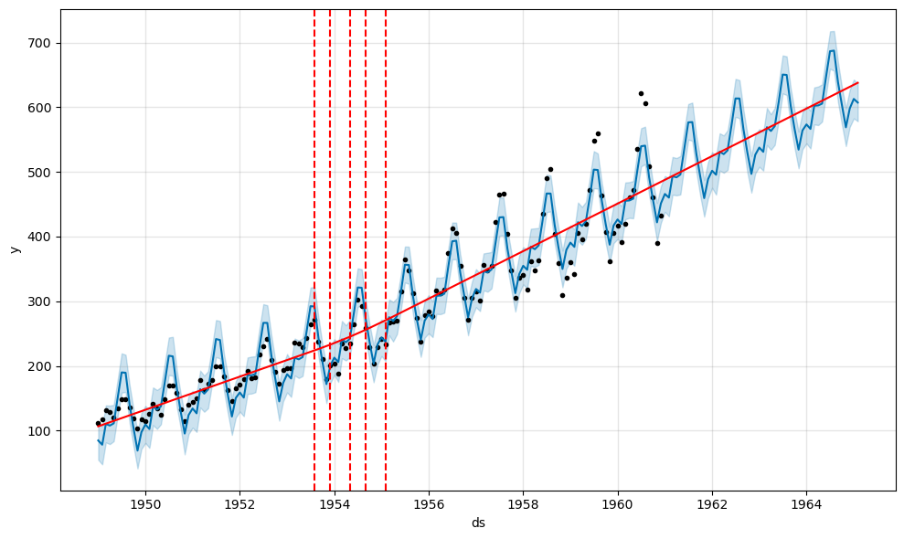

```python
fig = m.plot(forecasts)
a = add_changepoints_to_plot(fig.gca(), m, forecasts);
```

```
14:36:00 - cmdstanpy - INFO - Chain [1] start processing
14:36:00 - cmdstanpy - INFO - Chain [1] done processing
```

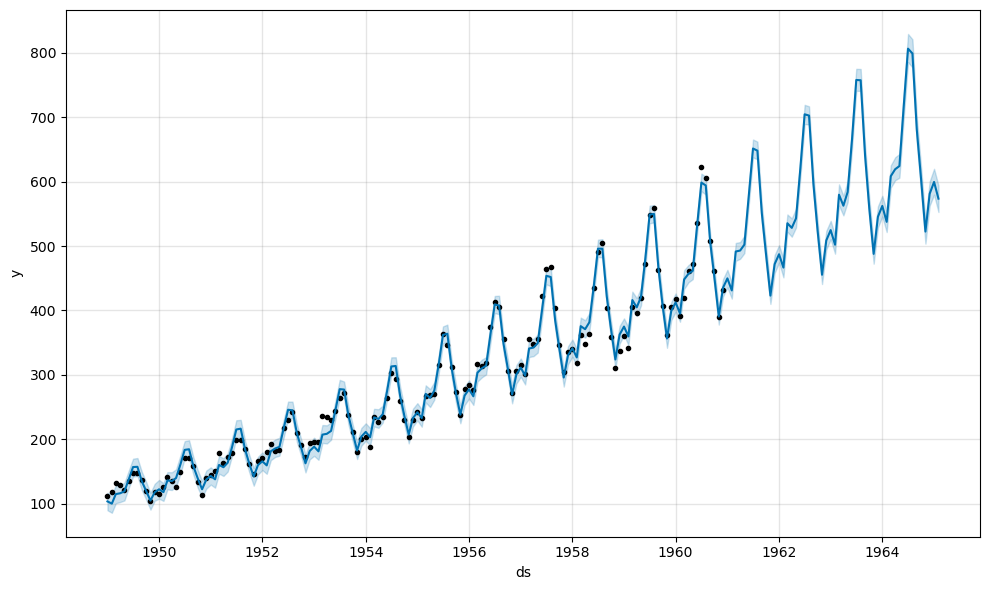

```python
### Now let's change seasonality to multiplicative

m = Prophet(seasonality_mode='multiplicative')
m.fit(df)
future = m.make_future_dataframe(periods=50, freq='MS')
forecasts = m.predict(future)
fig = m.plot(forecasts)

### Here we can see, forecasts capture the increase in trend and seasonality.
### We can also use train and test data to verify improvements.
```